# hw2_az2852

2025-03-14

```r
library(caret)
library(tidymodels)
library(splines)
library(mgcv)
library(pdp)
library(earth)
library(tidyverse)
```

```r
library(ggplot2)
library(gridExtra)
college = read_csv("College.csv")
set.seed(2)

#prepare data
clean_college = janitor::clean_names(college) %>%
  select(-college)

data_split <- initial_split(clean_college, prop = 0.8)

# Extract the training and test data
train_data <- training(data_split)
test_data <- testing(data_split)
```

## 1(a)

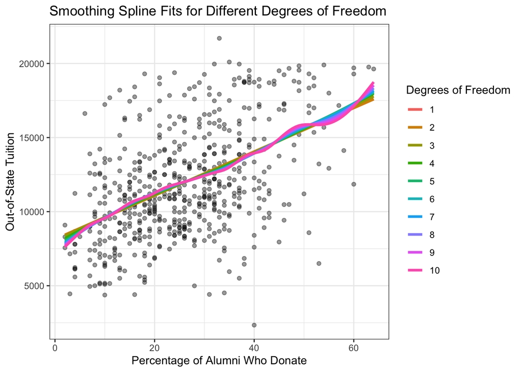

```r
set.seed(2)

# create grid for plotting
perc_alumni.grid <- seq(min(train_data$perc_alumni), max(train_data$perc_alumni), length.out = 100)

#range of df
df_values <- seq(1,10, by = 1)

pred_df <- data.frame()

for (df in df_values) {
  fit.ss <- smooth.spline(train_data$perc_alumni, train_data$outstate, df = df)
  pred.ss <- predict(fit.ss, x = perc_alumni.grid)

  temp_df <- data.frame(
    perc_alumni = perc_alumni.grid,
    pred = pred.ss$y,
    df = as.factor(df)
  )

  pred_df <- rbind(pred_df, temp_df)
}
p <- ggplot(clean_college, aes(x = perc_alumni, y = outstate)) +
  geom_point(alpha = 0.4) +  # Scatter plot of raw data
  theme_bw()

p + geom_line(data = pred_df, aes(x = perc_alumni, y = pred, color = df), size = 1.2) +
  labs(title = "Smoothing Spline Fits for Different Degrees of Freedom",
       x = "Percentage of Alumni Who Donate",
       y = "Out-of-State Tuition") +
  scale_color_discrete(name = "Degrees of Freedom")
```

At lower dfs, the model appears linear. As df increases, the curve becomes more wiggly, especially at the upper range of x values. Models with higher degrees of freedom caputure more fluctuations in the data, while it might be overly sensitive to small fluctuations.

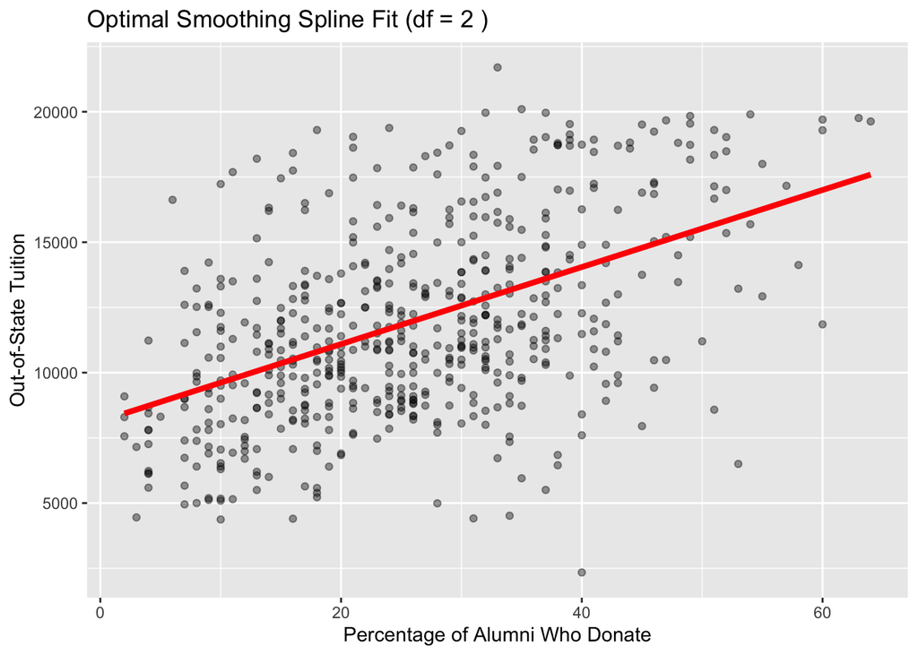

```r
best_df = 2

fit.best <- smooth.spline(train_data$perc_alumni, train_data$outstate, df = best_df)

#plot
perc_alumni.grid <- seq(min(clean_college$perc_alumni), max(clean_college$perc_alumni), length.out = 100)

pred.best <- predict(fit.best, x = perc_alumni.grid)

pred.best.df <- data.frame(pred = pred.best$y, perc_alumni = perc_alumni.grid)

ggplot(clean_college, aes(x = perc_alumni, y = outstate)) +
  geom_point(alpha = 0.4) +
  geom_line(data = pred.best.df, aes(x = perc_alumni, y = pred), color = "red", size = 1.5) +
  labs(title = paste("Optimal Smoothing Spline Fit (df =", best_df, ")"),
       x = "Percentage of Alumni Who Donate",
       y = "Out-of-State Tuition")
```

## (b)

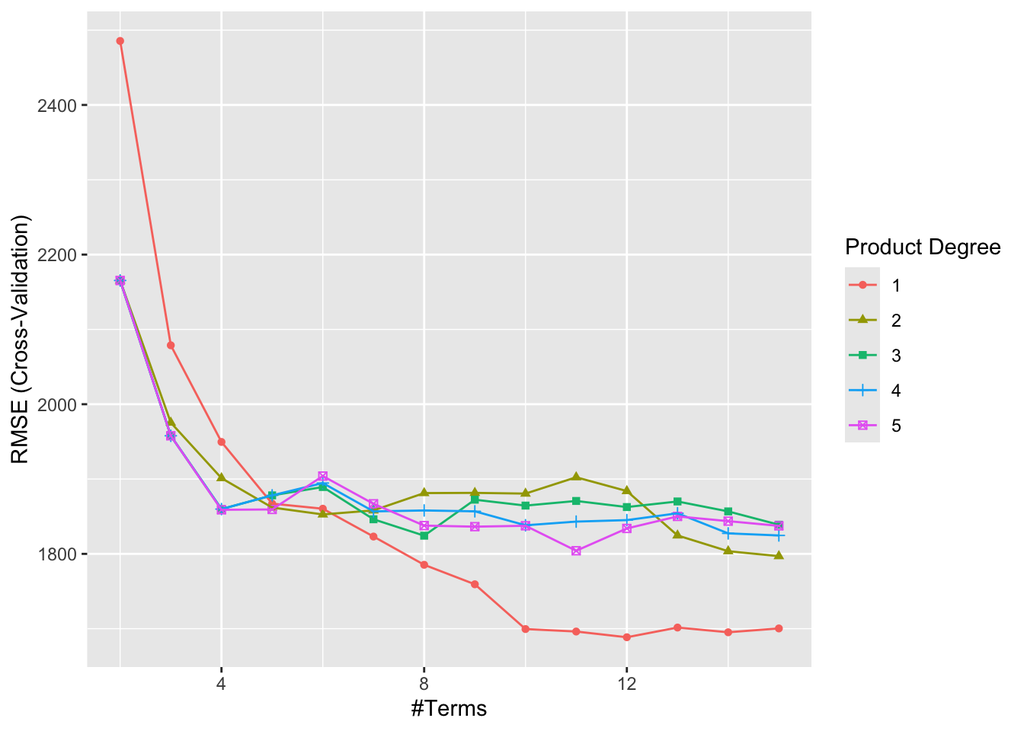

```r
mars_control <- trainControl(method = "cv", number = 10)
mars_grid <- expand.grid(degree = 1:5, nprune = 2:15)

mars_model <- train(
  outstate ~ .,
  data = train_data,
  method = "earth",
  tuneGrid = mars_grid,
  trControl = mars_control
)

ggplot(mars_model)
```

```r
best_mars_model <- mars_model$bestTune
print(best_mars_model)
```

```
##    nprune degree
## 11     12      1
```

```r
mars_coefficients <- coef(mars_model$finalModel)
print(mars_coefficients)
```

```
##         (Intercept)     h(expend-15387)     h(83-grad_rate)  h(5895-room_board)
##        9748.1790945          -0.7702870         -28.1240387          -0.6939388
## h(1363-f_undergrad)    h(1230-personal)        h(apps-3646)       h(enroll-913)
##          -1.9451538           0.8542158           0.4631943          -1.9848536
##       h(913-enroll)      h(2279-accept)    h(perc_alumni-6)      h(expend-6864)
##           6.3690181          -1.8971697          25.4427652           0.7506273
```

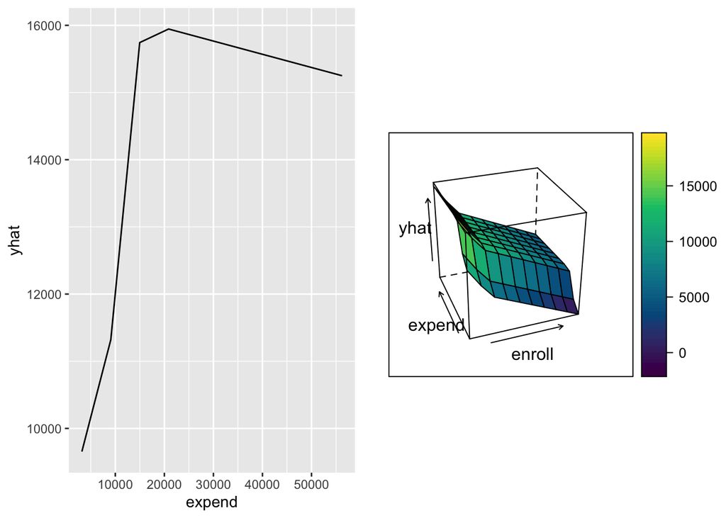

```r
p1 <- pdp::partial(mars_model, pred.var = "expend", grid.resolution = 10) %>% autoplot()

p2 <- pdp::partial(mars_model, pred.var = c("enroll", "expend"), grid.resolution = 10) %>%
  pdp::plotPartial(levelplot = FALSE, zlab = "yhat", drape = TRUE, screen = list(z = 20, x = -60))

grid.arrange(p1, p2, ncol = 2)
```

```r
mars_predictions <- predict(mars_model, newdata = test_data)


mars_mse <- mean((mars_predictions - test_data$outstate)^2)
print(paste("Test MSE for MARS model:", round(mars_mse, 2)))
```

```
## [1] "Test MSE for MARS model: 3436057.27"
```

### (c)

```r
gam_model <- gam(
  outstate ~ s(apps) + s(accept) + s(enroll) + s(top10perc) + s(top25perc) +
    s(f_undergrad) + s(p_undergrad) + s(room_board) + s(books) +
    s(personal) + s(ph_d) + s(terminal) + s(s_f_ratio) +
    s(perc_alumni) + s(expend) + s(grad_rate),
  data = train_data
)

summary(gam_model)
```

```
##
## Family: gaussian
## Link function: identity
##
## Formula:
## outstate ~ s(apps) + s(accept) + s(enroll) + s(top10perc) + s(top25perc) +
##     s(f_undergrad) + s(p_undergrad) + s(room_board) + s(books) +
##     s(personal) + s(ph_d) + s(terminal) + s(s_f_ratio) + s(perc_alumni) +
##     s(expend) + s(grad_rate)
##
## Parametric coefficients:
##             Estimate Std. Error t value Pr(>|t|)
## (Intercept) 11983.21      72.74   164.8   <2e-16 ***
## ---
## Signif. codes:  0 '***' 0.001 '**' 0.01 '*' 0.05 '.' 0.1 ' ' 1
##
## Approximate significance of smooth terms:
##                  edf Ref.df      F p-value
## s(apps)        3.893  4.771  2.102 0.06418 .
## s(accept)      2.841  3.546  3.652 0.00909 **
## s(enroll)      1.000  1.000 21.063 6.5e-06 ***
## s(top10perc)   7.586  8.419  1.812 0.04990 *
## s(top25perc)   1.000  1.000  2.486 0.11563
## s(f_undergrad) 6.167  7.200  3.397 0.00156 **
## s(p_undergrad) 1.000  1.000  0.228 0.63327
## s(room_board)  2.497  3.156 12.828 < 2e-16 ***
## s(books)       1.000  1.000  0.129 0.72010
## s(personal)    1.000  1.000  7.651 0.00593 **
## s(ph_d)        2.325  2.970  1.866 0.14357
## s(terminal)    1.000  1.000  1.699 0.19322
## s(s_f_ratio)   3.736  4.696  1.705 0.15362
## s(perc_alumni) 2.173  2.756  4.513 0.00704 **
## s(expend)      7.393  8.339 22.254 < 2e-16 ***
## s(grad_rate)   4.493  5.570  3.356 0.00399 **
## ---
## Signif. codes:  0 '***' 0.001 '**' 0.01 '*' 0.05 '.' 0.1 ' ' 1
##
## R-sq.(adj) =  0.836   Deviance explained = 85.4%
## GCV = 2.6894e+06  Scale est. = 2.3913e+06  n = 452
```

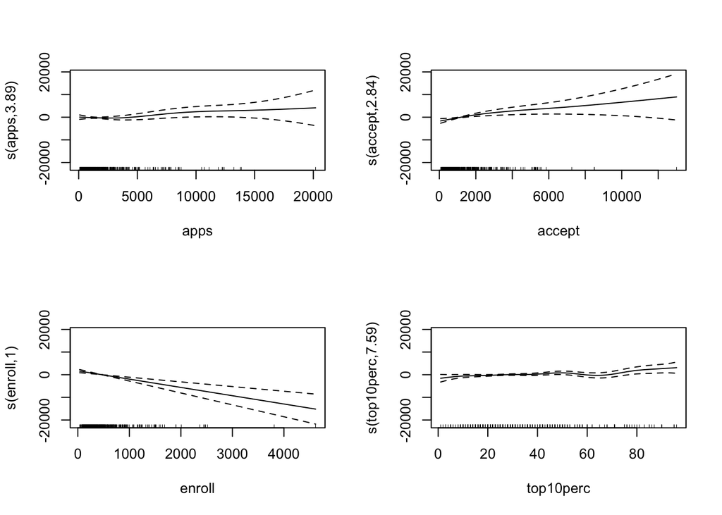

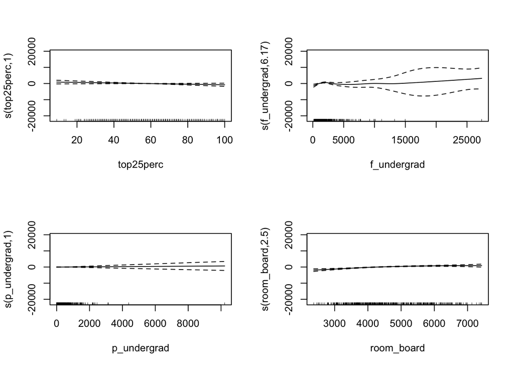

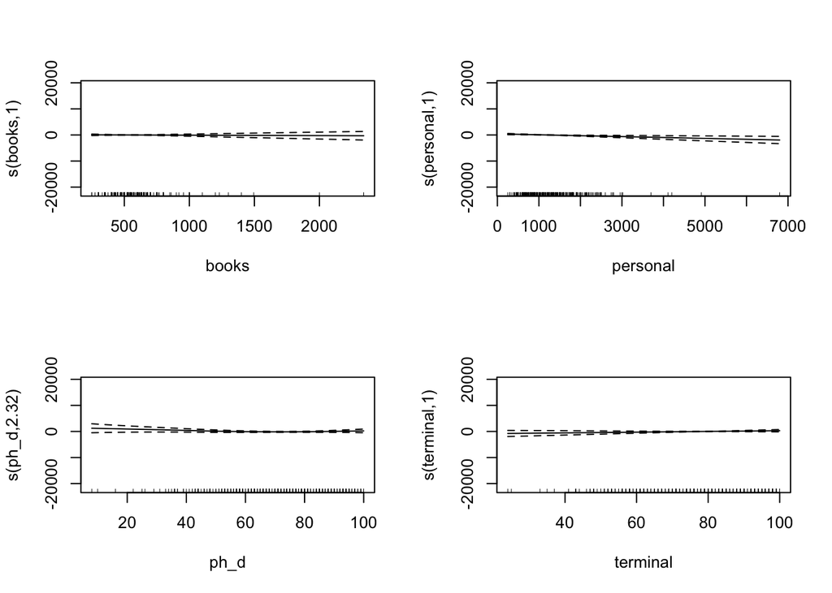

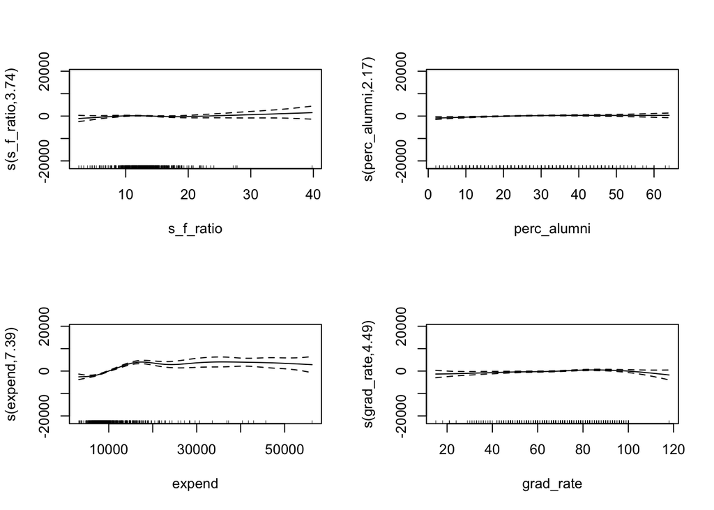

```r
plot.gam(gam_model, pages = 4)
```

```r
gam_predictions <- predict(gam_model, newdata = test_data, type = "response")

gam_mse <- mean((gam_predictions - test_data$outstate)^2)
print(paste("Test MSE for GAM model:", gam_mse))
```

```
## [1] "Test MSE for GAM model: 3434523.35877104"
```

## (d)

In this dataset, the GAM achieved a lower test MSE 3.4345234^{6} compared to the MARS model 3.4360573^{6}`, This suggests that GAM slightly outperforms MARS in predictive accuracy. However, the difference is small, which suggests that both models perform similarly.

In general, if the relationship between most predictors and response is nonlinear, a MARS model is preferable because it can automatically detect interactions and nonlinearities. But it might lead to the problem of overfitting. If the relationship is mostly linear, a GAM model might perform well, as it preserves linearity between the outcome and some predictors, which makes the model more simple and easier to interpret.

The decision depends on the underlying patterns in the data. If clear nonlinear patterns exist, MARS is worth considering; otherwise, a simpler model might be preferable.